# Analise da atividade dos parlamentares no Twitter no ano de 2019

Igor Matheus Castor Diniz Pinheiro

```r
atividade = read_projectdata()
glimpse(atividade)
```

```
Observations: 608
Variables: 19
$ id_parlamentar        <chr> "204554", "204521", "204379", "204560", "204528", "121948", "74646", "160508", "136811", "178835", "160527", "204495", "204549", "178836", "16…
$ casa                  <chr> "câmara", "câmara", "câmara", "câmara", "câmara", "câmara", "câmara", "câmara", "câmara", "câmara", "câmara", "câmara", "câmara", "câmara", "c…
$ nome_eleitoral        <chr> "ABÍLIO SANTANA", "ABOU ANNI", "ACÁCIO FAVACHO", "ADOLFO VIANA", "ADRIANA VENTURA", "ADRIANO DO BALDY", "AÉCIO NEVES", "AFONSO FLORENCE", "AFO…
$ partido               <chr> "PR", "PSL", "PROS", "PSDB", "NOVO", "PP", "PSDB", "PT", "PP", "PDT", "PP", "PT", "PP", "DEM", "MDB", "PRP", "PSL", "PT", "PSB", "PPS", "PDT",…
$ UF                    <chr> "BA", "SP", "AP", "BA", "SP", "GO", "MG", "BA", "RS", "RS", "PB", "PA", "CE", "AC", "RS", "GO", "MG", "SP", "RJ", "SP", "BA", "SP", "SP", "SP"…
$ twitter               <chr> "AbilioSantana_", "abouannipv", "FavachoAcacio", "AdolfoViana_", "adrianasounovo", "AdrianoBaldy", "AecioNeves", "AfonsoFlorence", "depafonso…
$ seguidores            <dbl> NA, NA, NA, NA, 4652, NA, NA, NA, NA, NA, NA, NA, NA, 3983, 6370, NA, 464, 6447, NA, NA, NA, 161745, 1134, 147085, 880, 6417, 17686, 5067, 418…
$ segue                 <dbl> NA, NA, NA, NA, 315, NA, NA, NA, NA, NA, NA, NA, NA, 995, 434, NA, 267, 3253, NA, NA, NA, 2015, 140, 1035, 41, 384, 2207, 957, 2381, NA, 118, …
$ n_proprio             <dbl> 0, 0, 0, 0, 99, 0, 0, 0, 0, 0, 0, 0, NA, 49, 214, NA, 39, 346, 0, 0, NA, 830, 58, 485, 1, 201, 290, 70, 139, NA, 21, 22, 0, 0, NA, NA, 131, 0,…
$ n_retweet             <dbl> 0, 0, 0, 0, 9, 0, 0, 0, 0, 0, 0, 0, NA, 1, 30, NA, 4, 100, 0, 0, NA, 169, 15, 204, 1, 95, 45, 50, 108, NA, 0, 1, 0, 0, NA, NA, 12, 0, 0, 0, 0,…
$ engaj_total           <dbl> 0, 0, 0, 0, 7090, 0, 0, 0, 0, 0, 0, 0, NA, 4286, 6852, NA, 10231, 69348, 0, 0, NA, 566011, 30, 112251, 2, 39439, 88433, 75207, 8530, NA, 10, 5…
$ engaj_total_proprio   <dbl> 0, 0, 0, 0, 6701, 0, 0, 0, 0, 0, 0, 0, NA, 284, 2239, NA, 186, 47967, 0, 0, NA, 320063, 23, 89409, 1, 29860, 9732, 1126, 1198, NA, 10, 53, 0, …
$ engaj_total_retweet   <dbl> 0, 0, 0, 0, 389, 0, 0, 0, 0, 0, 0, 0, NA, 4002, 4613, NA, 10045, 21381, 0, 0, NA, 245948, 7, 22842, 1, 9579, 78701, 74081, 7332, NA, 0, 3, 0, …
$ engaj_mediano         <dbl> 0.0, 0.0, 0.0, 0.0, 26.5, 0.0, 0.0, 0.0, 0.0, 0.0, 0.0, 0.0, NA, 4.0, 8.0, NA, 4.0, 16.5, 0.0, 0.0, NA, 134.0, 0.0, 49.0, 1.0, 67.0, 12.0, 6.0…
$ engaj_mediano_proprio <dbl> 0.0, 0.0, 0.0, 0.0, 22.5, 0.0, 0.0, 0.0, 0.0, 0.0, 0.0, 0.0, NA, 4.0, 8.0, NA, 4.0, 12.0, 0.0, 0.0, NA, 60.0, 0.0, 27.0, 0.5, 22.0, 8.0, 1.5, …
$ engaj_mediano_retweet <dbl> 0.0, 0.0, 0.0, 0.0, 0.0, 0.0, 0.0, 0.0, 0.0, 0.0, 0.0, 0.0, NA, 0.0, 0.0, NA, 0.0, 0.0, 0.0, 0.0, NA, 0.0, 0.0, 0.0, 0.5, 0.0, 0.0, 0.0, 0.0, …
$ engaj_max             <dbl> 0, 0, 0, 0, 1031, 0, 0, 0, 0, 0, 0, 0, NA, 4002, 4227, NA, 8171, 12335, 0, 0, NA, 20348, 4, 3643, 1, 1834, 27800, 25704, 1129, NA, 4, 8, 0, 0,…
$ engaj_max_proprio     <dbl> 0, 0, 0, 0, 1031, 0, 0, 0, 0, 0, 0, 0, NA, 38, 136, NA, 14, 12335, 0, 0, NA, 7271, 4, 3643, 1, 1834, 976, 191, 149, NA, 4, 8, 0, 0, NA, NA, 10…
$ engaj_max_retweet     <dbl> 0, 0, 0, 0, 99, 0, 0, 0, 0, 0, 0, 0, NA, 4002, 4227, NA, 8171, 8623, 0, 0, NA, 20348, 2, 3302, 1, 1575, 27800, 25704, 1129, NA, 0, 3, 0, 0, NA…
```

# Existe uma relação entre o numero de vonteúdo próprio e número de seguidores?

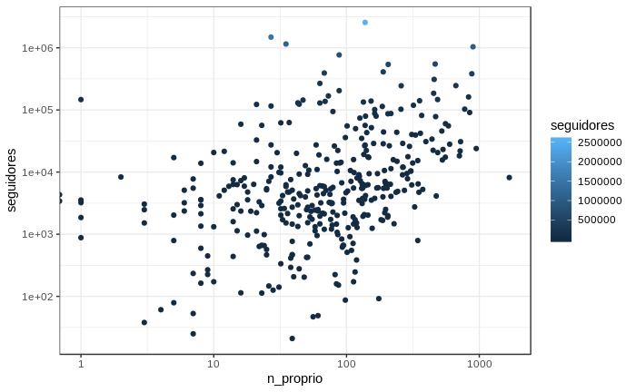

```r
atividade %>%
  na.omit(atividade)%>%
  ggplot(aes(x=n_proprio, y=seguidores, color=seguidores))+
  geom_point()+
  scale_x_log10()+
  scale_y_log10()
```

```r
atividade %>%
  na.omit(atividade)%>%
  summarise(correlacao = cor(n_proprio, seguidores, method = "pearson"),
            spearman = cor(n_proprio, seguidores, method = "spearman"),
            kendall = cor(n_proprio, seguidores, method = "kendall"))
```

| correlacao | spearman | kendall |
| --- | --- | --- |
| 0.1379111 | 0.4300526 | 0.2935345 |

Pelo gráfico tem-se uma impressão de que existe sim uma relação entre o número de conteúdo próprio produzido pelo parlamentar e o número de seguidores. Visualmente falando, pode-se concluir que quanto mais conteúdo próprio é produzido, maior será o número de seguidores que o parlamentar irá acumular. Entretanto ao analisarmos os coeficientes de correlação encontramos os seguintes resultados

Dessa forma, podemos concluir que o número de conteúdo próprio não tem tanto impacto no número de seguidores de um parlamentar.

# O numero de conteúdo próprio tem forte influência no nivel de engajamento do parlamentar?

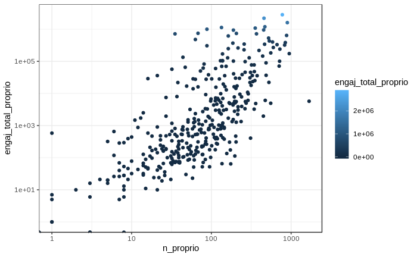

```r
atividade %>%
  na.omit(atividade)%>%
  ggplot(aes(x=n_proprio, y=engaj_total_proprio, color=engaj_total_proprio))+
  geom_point()+
  scale_x_log10()+
  scale_y_log10()
```

```r
atividade %>%
  na.omit(atividade)%>%
  summarise(correlacao = cor(n_proprio, engaj_total_proprio, method = "pearson"),
            spearman = cor(n_proprio, engaj_total_proprio, method = "spearman"),
            kendall = cor(n_proprio, engaj_total_proprio, method = "kendall"))
```

| correlacao | spearman | kendall |
| --- | --- | --- |
| 0.422698 | 0.7448931 | 0.5634754 |

Semelhantemente a questão anterior pelo gráfico tem-se uma impressão de que existe sim uma relação entre o número de conteúdo próprio produzido pelo parlamentar e o e o engajamento total em conteúdo próprio. Visualmente falando, pode-se concluir que quanto mais conteúdo próprio é produzido, maior será o engajamento, maior será o núemro de reações no conteúdo próprio. O que é algo realmente esperado, quanto mais eu produzo existe a esperança de que mais engajamento seja gerado. Ao analisarmos os coeficientes de correlação encontramos os seguintes resultados

- Coef. de Pearson: Como o valor está entre 0,3-0,5, por convenção temos uma correlação fraca para este coeficiente.
- Coef. Spearman: A correlação de Spearman avalia a relação monotônica entre duas variáveis contínuas ou ordinais e geralmente as variáveis tendem a mudar juntas mas não necessariamente a uma taxa constante. Para este caso temos um valor de correlação bastante considerável, indicado que existe sim uma correlação.
- Coef. Kendall: O coeficiente de concordância de Kendall pode variar de 0 a 1. Quanto maior o valor de Kendall, mais forte é a concordância. Para o caso em questão, temos um valor acima da metade do espectro de avaliação, o que fortalece a ideia de que existe uma correlação entre as variáveis.

Dessa forma, podemos concluir que o número de conteúdo próprio tem um certo impacto no número de engajamento total próprio.